# p5 slides

## Question

### Q 1. What is the distribution of borrowers based upon the income range?

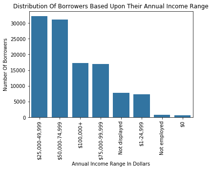

```python
#univariate Exploration about income range.
base_color = sb.color_palette()[0]
b_order = df['IncomeRange'].value_counts().index
sb.countplot(data = df, x = 'IncomeRange', color = base_color, order = b_order )
plt.xticks(rotation = 90)
plt.title("Distribution Of Borrowers Based Upon Their Annual Income Range")
plt.ylabel("Number Of Borrowers")
plt.xlabel("Annual Income Range In Dollars");
```

Most many borrower fall under the category of Annual Income range of dollars 25,000 - 49,999 and dollars 50,000 - 74,999, which are nearly double than any other categories when compared individually.

### Q 2. Is there a relationship that exists between Income Range and Gross Principal Loss ?

(Gross Principal Loss - The gross charged off amount of the loan.)

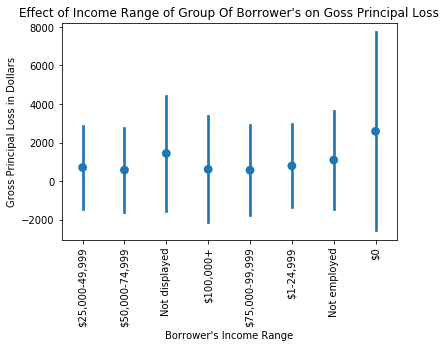

```python
# Bivariate Exploration
base_color = sb.color_palette()[0]
sb.pointplot(data = df, x = 'IncomeRange', y = 'LP_GrossPrincipalLoss', color = base_color, ci = 'sd', linestyles= " ")
plt.xticks(rotation = 90)
plt.title('Relationship between Income Range and Gross Principal loss')
plt.title("Effect of Income Range of Group Of Borrower's on Goss Principal Loss")
plt.ylabel("Gross Principal Loss in Dollars")
plt.xlabel("Borrower's Income Range");
```

From the above figure we can say that different group of borrowers based upon Income Range showed different Gross Principal Losses.

### Q 3. Whether their exist any relationship between Original Loan Amount and Gross Principal Loss with Credit Grade?

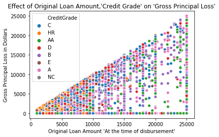

```python
# Multivariate Exploration
sb.scatterplot(data = df, y = 'LP_GrossPrincipalLoss', x = 'LoanOriginalAmount', hue = 'CreditGrade')
plt.title("Effect of Original Loan Amount,'Credit Grade' on 'Gross Principal Loss'")
plt.ylabel("Gross Principal Loss in Dollars")
plt.xlabel("Original Loan Amount 'At the time of disbursement'");
```

From the above multivariate figure it can be identified that there exists a relation between Original Loan Amount and Gross Principal Loss alongwith credit grade. As, Number of Loans with Gross Principal loss in smaller ticket size loans are more than Larger Loans and mostly Credit grade HR, C and D are occupying places less than 10000 dollars amount. Whereas, for large loans(Amounting Greater than dollars 10000) mostly AA, B and A are occupying places in figure. Though, for larger amounting loan the density is less but severity of hitting a loss is also high. Hence, both the factors should be taken into consideration before strategising.

### Q 4. Does Credit Grading has any effect on Gross Principal Loss ?

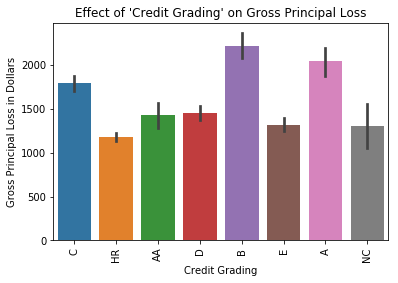

```python
# Bivariate Exploration
sb.barplot(data = df, y = 'LP_GrossPrincipalLoss', x = 'CreditGrade')
plt.xticks(rotation = 90);
plt.title("Effect of 'Credit Grading' on Gross Principal Loss")
plt.ylabel("Gross Principal Loss in Dollars")
plt.xlabel("Credit Grading");
```

From the above figure it can be seen that Credit Grading Categories like HR, E, NC are showing the least Gross Pricipal Losses. Whereas, Credit Grading like B, A and C are showing highest Gross Principal Losses.

### Q 5. Is there a combined effect of Credit Grade and Borrower owning a Home or Mortgage Loan History on Gross Principal Loss ?

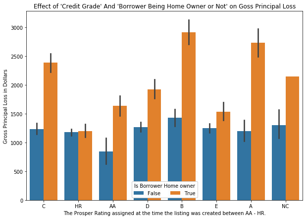

```python
# Multivariate
plt.figure(figsize= (10, 7))
ax = sb.barplot(data = df, x = 'CreditGrade', y = 'LP_GrossPrincipalLoss', hue = 'IsBorrowerHomeowner')
ax.legend(loc = 8, ncol = 3, framealpha = 4, title = 'Is Borrower Home owner')
plt.title("Effect of 'Credit Grade' And 'Borrower Being Home Owner or Not' on Goss Principal Loss")
plt.ylabel("Gross Principal Loss in Dollars")
plt.xlabel("The Prosper Rating assigned at the time the listing was created between AA - HR.");
```

The ones with Prosper Rating A,B and C and having a mortgage on their credit profile or provide documentation confirming they are a homeowner are most likely to hit Gross Principal Loss on the balance sheet of Prosper Loans. In contrast to the group of Borrowers having Prosper Rating AA, A and HR and not having a mortgage on their credit profile or provided any documention confirming the same are least likely to show Gross Principal Losses and so they are least risky borrowers to whom loans can be disbersed. Although, its just an insight and needs further investigation.

### Q 6. Is Income Range and Borrower Being Home Owner has effect on Gross Principal Loss?

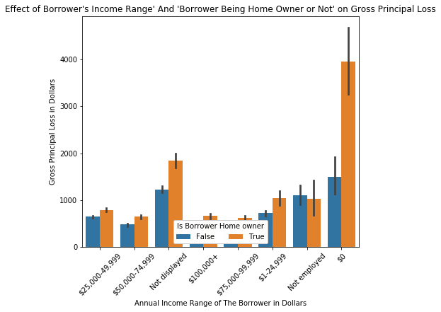

```python
# Multivariate
plt.figure(figsize= (7,6))
ax = sb.barplot(data = df, x = 'IncomeRange', y = 'LP_GrossPrincipalLoss', hue = 'IsBorrowerHomeowner')
ax.legend(loc = 8, ncol = 3, framealpha = 2, title = 'Is Borrower Home owner')
plt.title("Effect of Borrower's Income Range' And 'Borrower Being Home Owner or Not' on Gross Principal Loss")
plt.ylabel("Gross Principal Loss in Dollars")
plt.xlabel("Annual Income Range of The Borrower in Dollars")
plt.xticks(rotation = 45);
```

The ones with Zero Income and the ones with income 'Not Displayed' but having a mortgage on their credit profile or provided documentation confirming they are a homeowner are most likely to hit Gross Principal Loss on the balance sheet of Prosper Loans. In contrast, the group of loanees with income range dollars (100,000+) & dollars (75000 - 99,999) with no mortgage on their credit profile or have'nt provided documentation confirming being homeowner are best prospects which can boost in increasing the profitabilty for Prosper Loans as these group of Borrower are having least Gross Principal Losses. Hence, these above mentioned income groups and not owning a home categories can be a good focus areas for the Proper Group.

Although, this is just an insight and needs further investigation. Not employed category Group being an exception with no mortgage on credit profile is having high Gross Principal Losses could be due to some other reason not known.

### Q 7. Does Prosper Score (A Custom Risk Score Built By Prosper Historical Data) and Term Of The Loan has any effect on the Gross Principal Loss?

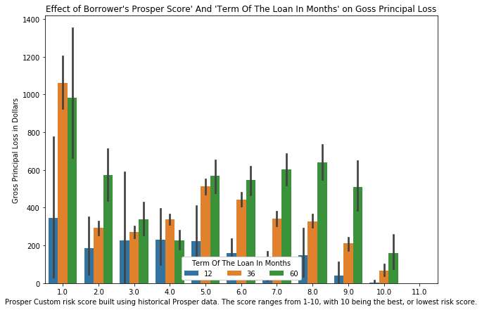

```python
# Multivariate Plot
plt.figure(figsize= (10, 7))
ax = sb.barplot(data = df, x = 'ProsperScore', y = 'LP_GrossPrincipalLoss', hue = 'Term')
ax.legend(loc = 8, ncol = 3, framealpha = 2, title = 'Term Of The Loan In Months')
plt.title("Effect of Borrower's Prosper Score' And 'Term Of The Loan In Months' on Goss Principal Loss")
plt.ylabel("Gross Principal Loss in Dollars")
plt.xlabel("Prosper Custom risk score built using historical Prosper data. The score ranges from 1-10, with 10 being the best, or lowest risk score.");
```

## Some exploration Lead to dead end in finding answer and certain exploration lead to great interesting insights. Hence, Summary of the findings in a nutshell are as below. (Albiet, these are just insights and has its limitations.)

### Summary:

(2) Most many borrower fall under the category of Annual Income range of dollars 25,000 - 49,999 and dollars 50,000 - 74,999, both are nearly double than any other categories when compared individually.

(3) Different group of borrowers based upon Income Range showed different Gross Principal Losses.

(4) There exists a relation between Original Loan Amount and Gross Principal Loss alongwith credit grade. As, Number of Loans with Gross Principal loss in smaller ticket size loans are more than Larger Loans and mostly Credit grade HR, C and D are occupying places less than 10000 dollars amount. Whereas, for large loans(Amounting Greater than dollars 10000) mostly AA, B and A are occupying places in figure. Though, for larger amounting loan the density is less but severity of hitting a loss is also high. Hence, both the factors should be taken into consideration before strategising.

(6) It can be seen that Credit Grading Categories like HR, E, NC are showing the least Gross Pricipal Losses. Whereas, Credit Grading like B, A and C are showing highest Gross Principal Losses.

(8) The ones with Prosper Rating A,B and C and having a mortgage on their credit profile or provide documentation confirming they are a homeowner are most likely to hit Gross Principal Loss on the balance sheet of Prosper Loans. In contrast to the group of Borrowers having Prosper Rating AA, A and HR and not having a mortgage on their credit profile or provided any documention confirming the same are least likely to show Gross Principal Losses and so they are least risky borrowers to whom loans can be disbersed. Although, its just an insight and needs further investigation.

(9) The ones with Zero Income and the ones with income 'Not Displayed' but having a mortgage on their credit profile or provided documentation confirming they are a homeowner are most likely to hit Gross Principal Loss on the balance sheet of Prosper Loans. In contrast, the group of loanees with income range dollars (100,000+) & dollars (75000 - 99,999) with no mortgage on their credit profile or have'nt provided documentation confirming being homeowner are best prospects which can boost in increasing the profitabilty for Prosper Loans as these group of Borrower are having least Gross Principal Losses. Hence, these above mentioned income groups and not owning a home categories can be a good focus areas for the Proper Group.